# Análisis narrativo del Titanic: datos, limpieza y modelos en Python

> **Prerequisito recomendado:** si aún no dominas CSV, Pandas y NumPy, empieza con `fundamentos_csv_pandas_numpy.ipynb`.

Este notebook usa el dataset clásico del **Titanic** para practicar un flujo completo de trabajo con datos:

- cargar y entender una tabla,
- detectar problemas de calidad,
- limpiar valores faltantes y tipos incorrectos,
- crear variables nuevas a partir de la información existente,
- explorar patrones con tablas y gráficas,
- construir un modelo logístico para estimar probabilidad de supervivencia.

La idea no es predecir con precisión perfecta, sino **aprender a manejar información real**: incompleta, desordenada y con decisiones de limpieza que afectan el análisis.

```python
!pip install statsmodels scikit-learn
```

[output not shown]

```python
import pandas as pd
import numpy as np
import matplotlib.pyplot as plt
import statsmodels.api as sm
import statsmodels.formula.api as smf
from sklearn.model_selection import train_test_split
from sklearn.metrics import accuracy_score, confusion_matrix, classification_report

plt.rcParams["figure.figsize"] = (8, 5)
plt.rcParams["axes.grid"] = True
```

## 1. Carga de datos

Cada fila representa un pasajero del Titanic. Las columnas más importantes son:

- `Survived`: si sobrevivió (`1`) o no (`0`).
- `Pclass`: clase del ticket (`1`, `2` o `3`).
- `Sex`: sexo del pasajero.
- `Age`: edad en años.
- `SibSp`: hermanos o cónyuge a bordo.
- `Parch`: padres o hijos a bordo.
- `Fare`: precio del boleto.
- `Embarked`: puerto de embarque (`C`, `Q` o `S`).
- `Cabin`: número de cabina (muchos valores faltantes).
- `Name`: nombre completo del pasajero.

Usaremos un CSV local en `data/titanic.csv`. Si no existe, intentamos descargarlo desde una URL pública.

```python
from pathlib import Path

REPO_ROOT = Path.cwd() if (Path.cwd() / "data").exists() else Path.cwd().parent
DATA_PATH = REPO_ROOT / "data" / "titanic.csv"
DATA_URL = "https://raw.githubusercontent.com/datasciencedojo/datasets/master/titanic.csv"

if DATA_PATH.exists():
    df_original = pd.read_csv(DATA_PATH)
else:
    df_original = pd.read_csv(DATA_URL)
    DATA_PATH.parent.mkdir(parents=True, exist_ok=True)
    df_original.to_csv(DATA_PATH, index=False)

print("Filas y columnas originales:", df_original.shape)
df_original.head()
```

```
Filas y columnas originales: (891, 12)
```

|  | PassengerId | Survived | Pclass | Name | Sex | Age | SibSp | Parch | Ticket | Fare | Cabin | Embarked |
| --- | --- | --- | --- | --- | --- | --- | --- | --- | --- | --- | --- | --- |
| 0 | 1 | 0 | 3 | Braund, Mr. Owen Harris | male | 22.0 | 1 | 0 | A/5 21171 | 7.2500 | NaN | S |
| 1 | 2 | 1 | 1 | Cumings, Mrs. John Bradley (Florence Briggs Th... | female | 38.0 | 1 | 0 | PC 17599 | 71.2833 | C85 | C |
| 2 | 3 | 1 | 3 | Heikkinen, Miss. Laina | female | 26.0 | 0 | 0 | STON/O2. 3101282 | 7.9250 | NaN | S |
| 3 | 4 | 1 | 1 | Futrelle, Mrs. Jacques Heath (Lily May Peel) | female | 35.0 | 1 | 0 | 113803 | 53.1000 | C123 | S |
| 4 | 5 | 0 | 3 | Allen, Mr. William Henry | male | 35.0 | 0 | 0 | 373450 | 8.0500 | NaN | S |

## 2. Revisión inicial de los datos

Antes de limpiar, siempre conviene responder tres preguntas básicas:

1. ¿Qué columnas tengo?
2. ¿Qué tipo de dato tiene cada una?
3. ¿Hay valores faltantes o algo que no cuadre?

```python
print("Columnas disponibles:")
print(df_original.columns.tolist())

print("\nTipos de datos:")
display(df_original.dtypes.to_frame("tipo"))

print("\nValores faltantes por columna:")
missing = df_original.isnull().sum().sort_values(ascending=False)
missing_pct = (missing / len(df_original) * 100).round(1)
display(pd.DataFrame({"faltantes": missing, "porcentaje": missing_pct}))

print("\nResumen numérico:")
display(df_original.describe().T)

print("\nSupervivencia general:")
display(df_original["Survived"].value_counts().rename({0: "No sobrevivió", 1: "Sobrevivió"}))
```

```
Columnas disponibles:
['PassengerId', 'Survived', 'Pclass', 'Name', 'Sex', 'Age', 'SibSp', 'Parch', 'Ticket', 'Fare', 'Cabin', 'Embarked']

Tipos de datos:
```

|  | tipo |
| --- | --- |
| PassengerId | int64 |
| Survived | int64 |
| Pclass | int64 |
| Name | str |
| Sex | str |
| Age | float64 |
| SibSp | int64 |
| Parch | int64 |
| Ticket | str |
| Fare | float64 |
| Cabin | str |
| Embarked | str |

```
Valores faltantes por columna:
```

|  | faltantes | porcentaje |
| --- | --- | --- |
| Cabin | 687 | 77.1 |
| Age | 177 | 19.9 |
| Embarked | 2 | 0.2 |
| PassengerId | 0 | 0.0 |
| Name | 0 | 0.0 |
| Pclass | 0 | 0.0 |
| Survived | 0 | 0.0 |
| Sex | 0 | 0.0 |
| Parch | 0 | 0.0 |
| SibSp | 0 | 0.0 |
| Fare | 0 | 0.0 |
| Ticket | 0 | 0.0 |

```
Resumen numérico:
```

|  | count | mean | std | min | 25% | 50% | 75% | max |
| --- | --- | --- | --- | --- | --- | --- | --- | --- |
| PassengerId | 891.0 | 446.000000 | 257.353842 | 1.00 | 223.5000 | 446.0000 | 668.5 | 891.0000 |
| Survived | 891.0 | 0.383838 | 0.486592 | 0.00 | 0.0000 | 0.0000 | 1.0 | 1.0000 |
| Pclass | 891.0 | 2.308642 | 0.836071 | 1.00 | 2.0000 | 3.0000 | 3.0 | 3.0000 |
| Age | 714.0 | 29.699118 | 14.526497 | 0.42 | 20.1250 | 28.0000 | 38.0 | 80.0000 |
| SibSp | 891.0 | 0.523008 | 1.102743 | 0.00 | 0.0000 | 0.0000 | 1.0 | 8.0000 |
| Parch | 891.0 | 0.381594 | 0.806057 | 0.00 | 0.0000 | 0.0000 | 0.0 | 6.0000 |
| Fare | 891.0 | 32.204208 | 49.693429 | 0.00 | 7.9104 | 14.4542 | 31.0 | 512.3292 |

```
Supervivencia general:
```

```
Survived
No sobrevivió    549
Sobrevivió       342
Name: count, dtype: int64
```

## 3. Auditoría de calidad

La limpieza empieza con un diagnóstico. Revisamos:

1. **Duplicados**: filas repetidas que podrían inflar conteos.
2. **Valores imposibles**: edades negativas, tarifas negativas, clases fuera de rango.
3. **Cardinalidad**: cuántos valores distintos tiene cada columna categórica.
4. **Consistencia**: si los tipos de datos coinciden con el significado de la columna.

Esta auditoría nos dice *qué* hay que corregir y *por qué*.

```python
print("--- Auditoría de calidad ---")

duplicados = df_original.duplicated().sum()
print("Filas duplicadas:", duplicados)

print("\nEdades negativas:", (df_original["Age"] < 0).sum())
print("Tarifas negativas:", (df_original["Fare"] < 0).sum())
print("Clases inválidas:", (~df_original["Pclass"].isin([1, 2, 3])).sum())

print("\nValores únicos por columna:")
for col in df_original.columns:
    print(f"- {col}: {df_original[col].nunique()}")

print("\nDistribución de sexo:")
display(df_original["Sex"].value_counts())

print("\nDistribución de puerto de embarque:")
display(df_original["Embarked"].value_counts(dropna=False))
```

```
--- Auditoría de calidad ---
Filas duplicadas: 0

Edades negativas: 0
Tarifas negativas: 0
Clases inválidas: 0

Valores únicos por columna:
- PassengerId: 891
- Survived: 2
- Pclass: 3
- Name: 891
- Sex: 2
- Age: 88
- SibSp: 7
- Parch: 7
- Ticket: 681
- Fare: 248
- Cabin: 147
- Embarked: 3

Distribución de sexo:
```

```
Sex
male      577
female    314
Name: count, dtype: int64
```

```
Distribución de puerto de embarque:
```

```
Embarked
S      644
C      168
Q       77
NaN      2
Name: count, dtype: int64
```

## 4. Limpieza de datos

Vamos a limpiar paso a paso y documentar cada decisión.

### Decisiones de limpieza

1. **`Embarked`**: solo faltan 2 valores. Los reemplazamos por la moda (`S`), el puerto más frecuente.
2. **`Age`**: faltan 177 edades. En lugar de borrar esas filas, imputamos la **mediana por `Pclass` y `Sex`**, porque la edad depende mucho de la clase y del sexo.
3. **`Fare`**: si hubiera nulos, usaríamos la mediana por clase. Aquí no hay nulos, pero sí revisamos valores extremos.
4. **`Cabin`**: tiene demasiados faltantes para rellenar texto. Creamos `has_cabin` (`1` si había cabina registrada, `0` si no).
5. **Tipos**: convertimos variables categóricas a tipo `category` para ahorrar memoria y facilitar análisis.

> **Idea clave del curso:** no existe una sola forma "correcta" de limpiar. Cada decisión cambia el análisis. Por eso documentamos el criterio.

```python
print("--- Iniciando limpieza de datos ---")

df = df_original.copy()
filas_inicio = len(df)

# 1) Embarked: reemplazar nulos con la moda.
embarked_mode = df["Embarked"].mode(dropna=True)[0]
df["Embarked"] = df["Embarked"].fillna(embarked_mode)

# 2) Age: imputar mediana por Pclass + Sex.
age_median = df.groupby(["Pclass", "Sex"])["Age"].transform("median")
df["Age"] = df["Age"].fillna(age_median)

# 3) Fare: por si aparece algún nulo en otra versión del dataset.
fare_median = df.groupby("Pclass")["Fare"].transform("median")
df["Fare"] = df["Fare"].fillna(fare_median)

# 4) Cabin: crear indicador de si había cabina registrada.
df["has_cabin"] = df["Cabin"].notna().astype(int)

# 5) Tipos categóricos.
df["Sex"] = df["Sex"].astype("category")
df["Embarked"] = df["Embarked"].astype("category")
df["Pclass"] = df["Pclass"].astype("category")

# 6) Filtros de valores imposibles.
df = df[df["Age"] >= 0]
df = df[df["Fare"] >= 0]
df = df[df["Pclass"].isin([1, 2, 3])]

print(f"Filas al inicio: {filas_inicio}")
print(f"Filas después de limpieza: {len(df)}")
print(f"Filas eliminadas: {filas_inicio - len(df)}")

print("\nValores faltantes después de limpiar:")
display(df.isnull().sum().to_frame("faltantes"))

df.head()
```

```
--- Iniciando limpieza de datos ---
Filas al inicio: 891
Filas después de limpieza: 891
Filas eliminadas: 0

Valores faltantes después de limpiar:
```

|  | faltantes |
| --- | --- |
| PassengerId | 0 |
| Survived | 0 |
| Pclass | 0 |
| Name | 0 |
| Sex | 0 |
| Age | 0 |
| SibSp | 0 |
| Parch | 0 |
| Ticket | 0 |
| Fare | 0 |
| Cabin | 687 |
| Embarked | 0 |
| has_cabin | 0 |

|  | PassengerId | Survived | Pclass | Name | Sex | Age | SibSp | Parch | Ticket | Fare | Cabin | Embarked | has_cabin |
| --- | --- | --- | --- | --- | --- | --- | --- | --- | --- | --- | --- | --- | --- |
| 0 | 1 | 0 | 3 | Braund, Mr. Owen Harris | male | 22.0 | 1 | 0 | A/5 21171 | 7.2500 | NaN | S | 0 |
| 1 | 2 | 1 | 1 | Cumings, Mrs. John Bradley (Florence Briggs Th... | female | 38.0 | 1 | 0 | PC 17599 | 71.2833 | C85 | C | 1 |
| 2 | 3 | 1 | 3 | Heikkinen, Miss. Laina | female | 26.0 | 0 | 0 | STON/O2. 3101282 | 7.9250 | NaN | S | 0 |
| 3 | 4 | 1 | 1 | Futrelle, Mrs. Jacques Heath (Lily May Peel) | female | 35.0 | 1 | 0 | 113803 | 53.1000 | C123 | S | 1 |
| 4 | 5 | 0 | 3 | Allen, Mr. William Henry | male | 35.0 | 0 | 0 | 373450 | 8.0500 | NaN | S | 0 |

## 5. Creación de variables nuevas

Muchas veces la información útil no viene lista en una sola columna. Hay que **construirla**.

Crearemos:

- `family_size`: tamaño del grupo familiar a bordo (`SibSp + Parch + 1`).
- `is_alone`: `1` si viajaba solo, `0` si iba acompañado.
- `title`: título extraído del nombre (`Mr`, `Mrs`, `Miss`, etc.).
- `age_group`: rango de edad (`child`, `young_adult`, `adult`, `senior`).
- `fare_per_person`: tarifa dividida entre el tamaño del grupo.
- `is_child`: `1` si tiene menos de 18 años.

Estas variables ayudan a responder preguntas como:

- ¿Viajar solo cambió la probabilidad de sobrevivir?
- ¿Los niños tuvieron más probabilidades de ser rescatados?
- ¿El título social se relaciona con la supervivencia?

```python
# Tamaño del grupo familiar.
df["family_size"] = df["SibSp"] + df["Parch"] + 1

# Indicador de viaje solo.
df["is_alone"] = (df["family_size"] == 1).astype(int)

# Título a partir del nombre: texto entre coma y punto.
df["title"] = df["Name"].str.extract(r",\s*([^\.]+)\.", expand=False).str.strip()

# Agrupar títulos poco frecuentes en 'Other'.
title_counts = df["title"].value_counts()
rare_titles = title_counts[title_counts < 10].index
df["title"] = df["title"].replace(rare_titles, "Other")

# Grupos de edad.
bins = [0, 12, 25, 60, 120]
labels = ["child", "young_adult", "adult", "senior"]
df["age_group"] = pd.cut(df["Age"], bins=bins, labels=labels, right=False)

# Tarifa por persona del grupo.
df["fare_per_person"] = df["Fare"] / df["family_size"]

# Indicador de menor de edad.
df["is_child"] = (df["Age"] < 18).astype(int)

new_columns = [
    "family_size", "is_alone", "title", "age_group",
    "fare_per_person", "is_child", "has_cabin"
]

display(df[new_columns].head(10))

print("\nResumen de variables nuevas:")
display(df[new_columns].describe(include="all").T)

print("\nSupervivencia por sexo:")
display(pd.crosstab(df["Sex"], df["Survived"], normalize="index").round(3))

print("\nSupervivencia por clase:")
display(pd.crosstab(df["Pclass"], df["Survived"], normalize="index").round(3))
```

|  | family_size | is_alone | title | age_group | fare_per_person | is_child | has_cabin |
| --- | --- | --- | --- | --- | --- | --- | --- |
| 0 | 2 | 0 | Mr | young_adult | 3.62500 | 0 | 0 |
| 1 | 2 | 0 | Mrs | adult | 35.64165 | 0 | 1 |
| 2 | 1 | 1 | Miss | adult | 7.92500 | 0 | 0 |
| 3 | 2 | 0 | Mrs | adult | 26.55000 | 0 | 1 |
| 4 | 1 | 1 | Mr | adult | 8.05000 | 0 | 0 |
| 5 | 1 | 1 | Mr | adult | 8.45830 | 0 | 0 |
| 6 | 1 | 1 | Mr | adult | 51.86250 | 0 | 1 |
| 7 | 5 | 0 | Master | child | 4.21500 | 1 | 0 |
| 8 | 3 | 0 | Mrs | adult | 3.71110 | 0 | 0 |
| 9 | 2 | 0 | Mrs | young_adult | 15.03540 | 1 | 0 |

```
Resumen de variables nuevas:
```

|  | count | unique | top | freq | mean | std | min | 25% | 50% | 75% | max |
| --- | --- | --- | --- | --- | --- | --- | --- | --- | --- | --- | --- |
| family_size | 891.0 | NaN | NaN | NaN | 1.904602 | 1.613459 | 1.0 | 1.0 | 1.0 | 2.0 | 11.0 |
| is_alone | 891.0 | NaN | NaN | NaN | 0.602694 | 0.489615 | 0.0 | 0.0 | 1.0 | 1.0 | 1.0 |
| title | 891 | 5 | Mr | 517 | NaN | NaN | NaN | NaN | NaN | NaN | NaN |
| age_group | 891 | 4 | adult | 545 | NaN | NaN | NaN | NaN | NaN | NaN | NaN |
| fare_per_person | 891.0 | NaN | NaN | NaN | 19.916375 | 35.841257 | 0.0 | 7.25 | 8.3 | 23.666667 | 512.3292 |
| is_child | 891.0 | NaN | NaN | NaN | 0.126824 | 0.332962 | 0.0 | 0.0 | 0.0 | 0.0 | 1.0 |
| has_cabin | 891.0 | NaN | NaN | NaN | 0.228956 | 0.420397 | 0.0 | 0.0 | 0.0 | 0.0 | 1.0 |

```
Supervivencia por sexo:
```

| Survived Sex | 0 | 1 |
| --- | --- | --- |
| female | 0.258 | 0.742 |
| male | 0.811 | 0.189 |

```
Supervivencia por clase:
```

| Survived Pclass | 0 | 1 |
| --- | --- | --- |
| 1 | 0.370 | 0.630 |
| 2 | 0.527 | 0.473 |
| 3 | 0.758 | 0.242 |

## 6. Visualizaciones exploratorias

Las tablas resumen números, pero las gráficas ayudan a **ver patrones** más rápido.

Observa especialmente:

- la diferencia de supervivencia entre mujeres y hombres,
- cómo baja la supervivencia en clases más económicas,
- si los niños tuvieron mayor tasa de rescate,
- la relación entre tarifa y probabilidad de sobrevivir.

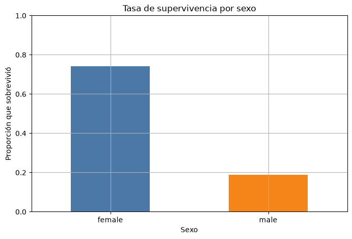

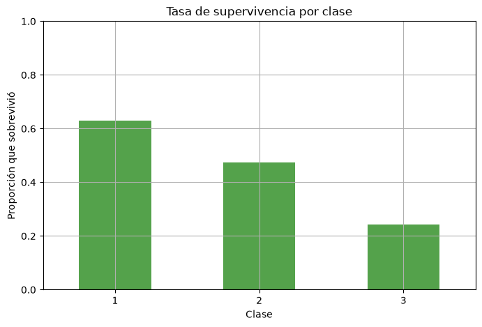

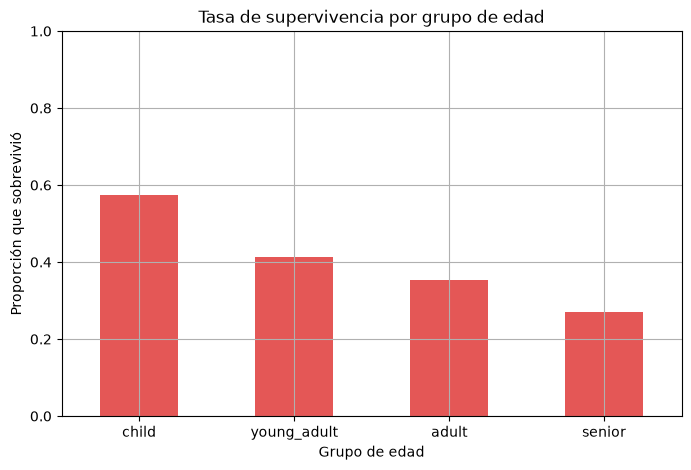

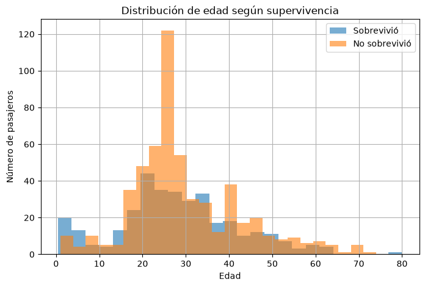

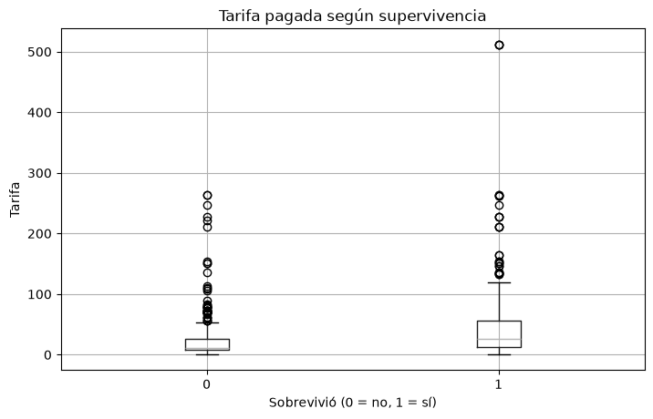

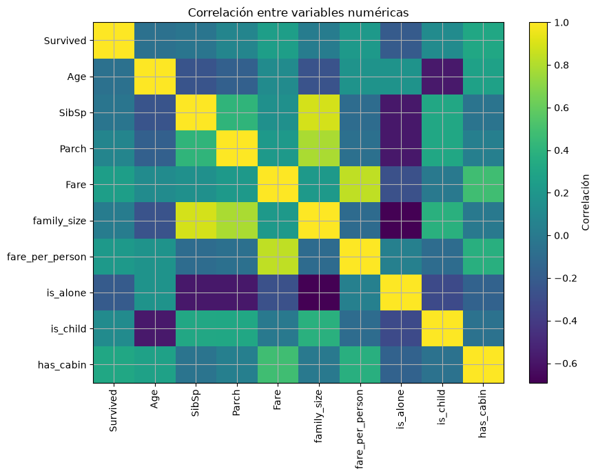

|  | Survived | Age | SibSp | Parch | Fare | family_size | fare_per_person | is_alone | is_child | has_cabin |
| --- | --- | --- | --- | --- | --- | --- | --- | --- | --- | --- |
| Survived | 1.00 | -0.06 | -0.04 | 0.08 | 0.26 | 0.02 | 0.22 | -0.20 | 0.12 | 0.32 |
| Age | -0.06 | 1.00 | -0.25 | -0.18 | 0.12 | -0.26 | 0.18 | 0.18 | -0.58 | 0.28 |
| SibSp | -0.04 | -0.25 | 1.00 | 0.41 | 0.16 | 0.89 | -0.09 | -0.58 | 0.32 | -0.04 |
| Parch | 0.08 | -0.18 | 0.41 | 1.00 | 0.22 | 0.78 | -0.07 | -0.58 | 0.32 | 0.04 |
| Fare | 0.26 | 0.12 | 0.16 | 0.22 | 1.00 | 0.22 | 0.84 | -0.27 | -0.01 | 0.48 |
| family_size | 0.02 | -0.26 | 0.89 | 0.78 | 0.22 | 1.00 | -0.10 | -0.69 | 0.38 | -0.01 |
| fare_per_person | 0.22 | 0.18 | -0.09 | -0.07 | 0.84 | -0.10 | 1.00 | 0.05 | -0.09 | 0.37 |
| is_alone | -0.20 | 0.18 | -0.58 | -0.58 | -0.27 | -0.69 | 0.05 | 1.00 | -0.31 | -0.16 |
| is_child | 0.12 | -0.58 | 0.32 | 0.32 | -0.01 | 0.38 | -0.09 | -0.31 | 1.00 | -0.06 |
| has_cabin | 0.32 | 0.28 | -0.04 | 0.04 | 0.48 | -0.01 | 0.37 | -0.16 | -0.06 | 1.00 |

```python
# Supervivencia por sexo.
survival_sex = df.groupby("Sex")["Survived"].mean()
survival_sex.plot(kind="bar", color=["#4C78A8", "#F58518"], title="Tasa de supervivencia por sexo")
plt.ylabel("Proporción que sobrevivió")
plt.xlabel("Sexo")
plt.xticks(rotation=0)
plt.ylim(0, 1)
plt.show()

# Supervivencia por clase.
survival_class = df.groupby("Pclass")["Survived"].mean()
survival_class.plot(kind="bar", color="#54A24B", title="Tasa de supervivencia por clase")
plt.ylabel("Proporción que sobrevivió")
plt.xlabel("Clase")
plt.xticks(rotation=0)
plt.ylim(0, 1)
plt.show()

# Supervivencia por grupo de edad.
survival_age = df.groupby("age_group", observed=True)["Survived"].mean()
survival_age.plot(kind="bar", color="#E45756", title="Tasa de supervivencia por grupo de edad")
plt.ylabel("Proporción que sobrevivió")
plt.xlabel("Grupo de edad")
plt.xticks(rotation=0)
plt.ylim(0, 1)
plt.show()

# Distribución de edad por supervivencia.
df[df["Survived"] == 1]["Age"].plot(kind="hist", bins=25, alpha=0.6, label="Sobrevivió")
df[df["Survived"] == 0]["Age"].plot(kind="hist", bins=25, alpha=0.6, label="No sobrevivió")
plt.title("Distribución de edad según supervivencia")
plt.xlabel("Edad")
plt.ylabel("Número de pasajeros")
plt.legend()
plt.show()

# Tarifa vs supervivencia.
df.boxplot(column="Fare", by="Survived", grid=True)
plt.title("Tarifa pagada según supervivencia")
plt.suptitle("")
plt.xlabel("Sobrevivió (0 = no, 1 = sí)")
plt.ylabel("Tarifa")
plt.show()

# Matriz de correlación entre variables numéricas.
corr_cols = ["Survived", "Age", "SibSp", "Parch", "Fare", "family_size", "fare_per_person", "is_alone", "is_child", "has_cabin"]
corr = df[corr_cols].corr()

plt.figure(figsize=(9, 7))
plt.imshow(corr, aspect="auto")
plt.colorbar(label="Correlación")
plt.xticks(range(len(corr.columns)), corr.columns, rotation=90)
plt.yticks(range(len(corr.columns)), corr.columns)
plt.title("Correlación entre variables numéricas")
plt.tight_layout()
plt.show()

display(corr.round(2))
```

## 7. Regresión logística de supervivencia

Después de limpiar y crear variables, podemos modelar la pregunta central:

> ¿Qué factores se asocian con la probabilidad de sobrevivir?

Usamos **regresión logística** porque `Survived` es binaria (`0` o `1`).

Variables del modelo:

- `Pclass`
- `Sex`
- `Age`
- `Fare`
- `family_size`
- `is_child`
- `has_cabin`

La fórmula con `statsmodels` nos permite interpretar coeficientes de forma parecida al notebook de nutrición.

```python
print("--- Regresión logística de supervivencia ---")

modelo_df = df[[
    "Survived", "Pclass", "Sex", "Age", "Fare",
    "family_size", "is_child", "has_cabin"
]].copy()

modelo_df["Sex"] = modelo_df["Sex"].astype(str)

formula = "Survived ~ C(Pclass) + C(Sex) + Age + Fare + family_size + is_child + has_cabin"
modelo_logit = smf.logit(formula, data=modelo_df).fit(disp=0)

display(modelo_logit.summary().tables[1])
print("Pseudo R-cuadrado:", round(modelo_logit.prsquared, 4))
```

```
--- Regresión logística de supervivencia ---
```

|  | coef | std err | z | P>\|z\| | [0.025 | 0.975] |
| --- | --- | --- | --- | --- | --- | --- |
| Intercept | 3.1445 | 0.583 | 5.396 | 0.000 | 2.002 | 4.287 |
| C(Pclass)[T.2] | -0.4022 | 0.391 | -1.028 | 0.304 | -1.169 | 0.364 |
| C(Pclass)[T.3] | -1.5510 | 0.406 | -3.824 | 0.000 | -2.346 | -0.756 |
| C(Sex)[T.male] | -2.7720 | 0.202 | -13.690 | 0.000 | -3.169 | -2.375 |
| Age | -0.0297 | 0.010 | -3.075 | 0.002 | -0.049 | -0.011 |
| Fare | 0.0033 | 0.003 | 1.300 | 0.194 | -0.002 | 0.008 |
| family_size | -0.3158 | 0.076 | -4.177 | 0.000 | -0.464 | -0.168 |
| is_child | 0.8721 | 0.361 | 2.415 | 0.016 | 0.164 | 1.580 |
| has_cabin | 0.8695 | 0.335 | 2.596 | 0.009 | 0.213 | 1.526 |

```
Pseudo R-cuadrado: 0.3489
```

### Interpretación del modelo logístico

En regresión logística, un coeficiente positivo indica que **aumenta la probabilidad** del evento (sobrevivir). Un coeficiente negativo indica lo contrario.

Ejemplos típicos en este dataset:

- `C(Sex)[T.male]` negativo → ser hombre se asocia con menor probabilidad de sobrevivir, comparado con mujeres.
- Coeficientes de `C(Pclass)` → a peor clase, menor probabilidad relativa de supervivencia.
- `is_child` positivo → los menores de edad tuvieron mayor probabilidad de ser rescatados.
- `has_cabin` positivo → tener cabina registrada puede reflejar mayor estatus o ubicación favorable en el barco.

El **Pseudo R-cuadrado** da una idea general del ajuste, pero no se interpreta igual que en regresión lineal.

## 8. Evaluación con train/test split

Para revisar si el modelo generaliza, separamos datos de entrenamiento y prueba.

Esto es importante en cualquier curso de datos: **no basta con ajustar bien en la misma muestra**; hay que probar con datos que el modelo no vio durante el entrenamiento.

```python
# Preparar matriz para sklearn usando las mismas variables.
X = pd.get_dummies(modelo_df.drop(columns=["Survived"]), drop_first=True)
y = modelo_df["Survived"]

X_train, X_test, y_train, y_test = train_test_split(
    X, y, test_size=0.2, random_state=42, stratify=y
)

# Ajustar con statsmodels en entrenamiento.
train_data = X_train.copy()
train_data["Survived"] = y_train.values

formula_cols = "Survived ~ " + " + ".join([c for c in train_data.columns if c != "Survived"])
modelo_train = smf.logit(formula_cols, data=train_data).fit(disp=0)

# Predecir probabilidades y clases en prueba.
probs = modelo_train.predict(X_test)
preds = (probs >= 0.5).astype(int)

print("Exactitud en prueba:", round(accuracy_score(y_test, preds), 4))
print("\nMatriz de confusión:")
display(pd.DataFrame(
    confusion_matrix(y_test, preds),
    index=["Real: No", "Real: Sí"],
    columns=["Pred: No", "Pred: Sí"]
))

print("\nReporte de clasificación:")
print(classification_report(y_test, preds, target_names=["No sobrevivió", "Sobrevivió"]))
```

```
Exactitud en prueba: 0.8101

Matriz de confusión:
```

|  | Pred: No | Pred: Sí |
| --- | --- | --- |
| Real: No | 97 | 13 |
| Real: Sí | 21 | 48 |

```
Reporte de clasificación:
               precision    recall  f1-score   support

No sobrevivió       0.82      0.88      0.85       110
   Sobrevivió       0.79      0.70      0.74        69

     accuracy                           0.81       179
    macro avg       0.80      0.79      0.79       179
 weighted avg       0.81      0.81      0.81       179
```

## 9. Resumen final: qué aprendimos sobre manejo de datos

En este notebook practicamos un flujo completo:

1. **Carga** del dataset y primera inspección.
2. **Auditoría** de calidad: nulos, duplicados, valores imposibles.
3. **Limpieza** con criterios explícitos (moda, mediana por grupo, variables derivadas).
4. **Ingeniería de variables** para capturar familia, edad, estatus y tarifa por persona.
5. **Exploración** con tablas y gráficas para entender patrones.
6. **Modelado logístico** para cuantificar asociaciones con la supervivencia.
7. **Evaluación** con partición train/test.

### Mensajes clave para el curso

- Los datos rara vez llegan listos: **la limpieza es parte del análisis**, no un paso menor.
- Cada decisión de imputación cambia resultados: conviene **documentar y justificar**.
- Las visualizaciones ayudan a detectar sesgos y relaciones antes de modelar.
- Un modelo puede ajustar bien, pero hay que interpretar con contexto histórico y ético.

La parte más importante no es solo correr el modelo, sino **saber leer la historia que cuentan los datos**.